# DTA interval mapping pilot on two mexicana donors (R/qtl)

Haley–Knott scanone on the RTIGER ancestry of the zealbc1 nb06 lines, TeoNAM JLM 0.1-cM grid, chr10 (2026-09-27)

Author

Fausto Rodríguez-Zapata

Published

September 26, 2026

**What this is.** The interval-mapping companion of notebook 02 (DTA GWAS), on the same 83 lines of the two mexicana donors (Zx.0540_P3, Zx.0570_P2) and the same phenotype, set up as zealhmm `scripts/zeal_rqtl_scan.R` / `analysis/zeal-rqtl-dta-lod-profile.qmd`:

- **Genotype = ancestry**, not alleles: each line’s RTIGER state (B73 = A, HET = H, donor = B), read from its segments at the marker positions (zealhmm projects its SNP50K mosaic by nearest marker; here the segments are looked up directly).
- **Markers and map** = the TeoNAM JLM 0.1-cM set (zealhmm `data/teonam/tassel/geno.hmp.txt`, v5 positions and TeoNAM cM from `data/teonam/teonam_v5_native.tsv`), chr10.
- **Cross** `bcsft` with BC.gen = 2, F.gen = 3 (BC2S3); `calc.genoprob(step = 1, error.prob = 0.01, haldane)`.
- **Scans**: Haley–Knott `scanone` without covariate and with family (donor) as an additive covariate (zealhmm uses taxon; here both donors are Zx), 1,000 permutations each; then per-family additive scans on the HMM expected dosage with zealhmm’s filters (≥ 5 % of the family introgressed, ≥ 3 lines in every present genotype class).
- **Phenotype**: zealhmm `data/zeal/pheno_dta_blue.csv`, `DTA_mean` (SpATS BLUE, CLY23 + CLY25), as in notebook 02. zealhmm’s R/qtl notebook uses the Clayton-only `DTA_CLY`.

```r
library(qtl)
library(data.table)
library(ggplot2)
set.seed(1234567890)
ZH <- "/Users/fvrodriguez/repos/zealhmm"
IN <- "../../agent/gwas_dta_20260927"
donors <- c("Zx.0540_P3", "Zx.0570_P2")
NPERM <- 1000L
ERR_PROB <- 0.01
INTRO_MIN <- 0.05
MIN_CLASS <- 3L
ZMCCT10 <- 96175873
theme_set(theme_bw(base_size = 11))
```

## 1. Markers, map and genotypes

```r
jlm_rs <- fread(file.path(ZH, "data/teonam/tassel/geno.hmp.txt"), select = 1L)[[1]]
tm <- fread(file.path(ZH, "data/teonam/teonam_v5_native.tsv"))
mk <- tm[match(jlm_rs, marker), .(chr = chr_v5, pos = pos_v5, cm)][!is.na(pos) & !is.na(cm) & chr == 10][order(pos)]
mk[, marker := sprintf("S10_%d", pos)]
mk <- mk[!duplicated(marker)]

state_at <- function(d) {
  seg <- fread(file.path(IN, sprintf("rtiger_%s_r500_chr10.csv", d)))
  sapply(unique(seg$name), function(ln) {
    s <- seg[name == ln][order(start_bp)]
    i <- findInterval(mk$pos, s$start_bp)
    ifelse(i > 0 & mk$pos <= s$end_bp[pmax(i, 1)], s$state[pmax(i, 1)], NA)
  })
}
S <- do.call(cbind, lapply(donors, state_at))
line_donor <- unlist(lapply(donors, function(d) setNames(rep(d, ncol(state_at(d))), colnames(state_at(d)))))

ss <- fread(file.path(ZH, "data/zeal/samplesheet_3way.csv"))[gwas_nil == TRUE]
ph <- fread(file.path(ZH, "data/zeal/pheno_dta_blue.csv"))
ped <- setNames(ss$pedigree, ss$skim_id)[colnames(S)]
fam <- setNames(ss$donor_accession, ss$skim_id)[colnames(S)]
y <- setNames(ph$DTA_mean, ph$Genotype)[ped]
ok <- is.finite(y) & !is.na(fam)
S <- S[, ok]; y <- as.numeric(y[ok]); fam <- factor(fam[ok]); ped <- ped[ok]
knitr::kable(data.table(
  quantity = c("JLM markers on chr10", "chr10 map length (TeoNAM cM)", "lines with DTA and family",
               "genotype fractions A / H / B", "cells without ancestry"),
  value = c(nrow(mk), round(max(mk$cm) - min(mk$cm), 1), paste(length(y), sprintf("(%s)", paste(names(table(fam)), table(fam), sep = ":", collapse = ", "))),
            paste(sprintf("%.3f", c(mean(S == 0, na.rm = TRUE), mean(S == 1, na.rm = TRUE), mean(S == 2, na.rm = TRUE))), collapse = " / "),
            sum(is.na(S)))))
```

| quantity | value |
| --- | --- |
| JLM markers on chr10 | 629 |
| chr10 map length (TeoNAM cM) | 120.3 |
| lines with DTA and family | 83 (Zx.0540:39, Zx.0570:44) |
| genotype fractions A / H / B | 0.863 / 0.086 / 0.051 |
| cells without ancestry | 74 |

## 2. Cross and genotype probabilities

```r
csv <- tempfile(fileext = ".csv")
Gc <- matrix(c("A", "H", "B")[t(S) + 1L], nrow = ncol(S)); Gc[is.na(Gc)] <- "-"
famcov <- as.integer(fam == levels(fam)[2])
top <- rbind(c("id", "DTA", "family", mk$marker), c("", "", "", rep("10", nrow(mk))), c("", "", "", sprintf("%.6f", mk$cm)))
body <- cbind(ped, formatC(y, format = "f", digits = 4), famcov, Gc)
fwrite(as.data.table(rbind(top, body)), csv, col.names = FALSE, quote = FALSE)
cross <- read.cross(format = "csv", file = csv, genotypes = c("A", "H", "B"), alleles = c("A", "B"), na.strings = "-",
                    estimate.map = FALSE, BC.gen = 2, F.gen = 3, crosstype = "bcsft")
```

```
 --Read the following data:
     83  individuals
     629  markers
     3  phenotypes
 --Cross type: bcsft
```

```r
cross <- jittermap(cross)
cross <- calc.genoprob(cross, step = 1, error.prob = ERR_PROB, map.function = "haldane")
cat(class(cross)[1], "|", nind(cross), "lines,", totmar(cross), "markers\n")
```

```
bcsft | 83 lines, 629 markers
```

## 3. Scans and permutation thresholds

```r
covar <- matrix(famcov, ncol = 1, dimnames = list(NULL, "family"))
one_nc <- scanone(cross, pheno.col = "DTA", method = "hk")
one_fc <- scanone(cross, pheno.col = "DTA", method = "hk", addcovar = covar)
perm_nc <- scanone(cross, pheno.col = "DTA", method = "hk", n.perm = NPERM, verbose = FALSE)
perm_fc <- scanone(cross, pheno.col = "DTA", method = "hk", addcovar = covar, n.perm = NPERM, verbose = FALSE)
thr <- c(nocovar = summary(perm_nc, alpha = 0.05)[1], family = summary(perm_fc, alpha = 0.05)[1])
pk <- function(one) { i <- which.max(one$lod); c(lod = one$lod[i], cM = one$pos[i]) }
cm_to_bp <- function(cm) approx(mk$cm, mk$pos, xout = cm, rule = 2)$y
res <- data.table(model = c("no covariate", "+ family"),
                  `5 % LOD threshold` = round(thr, 2),
                  `max LOD` = round(c(pk(one_nc)["lod"], pk(one_fc)["lod"]), 2),
                  `peak (cM)` = round(c(pk(one_nc)["cM"], pk(one_fc)["cM"]), 1),
                  `peak (Mb, v5)` = round(cm_to_bp(c(pk(one_nc)["cM"], pk(one_fc)["cM"])) / 1e6, 2),
                  `QTL (FWER 0.05)` = c(sum(one_nc$lod > thr[1]) > 0, sum(one_fc$lod > thr[2]) > 0))
knitr::kable(res)
```

| model | 5 % LOD threshold | max LOD | peak (cM) | peak (Mb, v5) | QTL (FWER 0.05) |
| --- | --- | --- | --- | --- | --- |
| no covariate | 3.76 | 3.23 | 65.3 | 134.6 | FALSE |
| + family | 3.78 | 3.24 | 65.3 | 134.6 | FALSE |

## 4. LOD profile

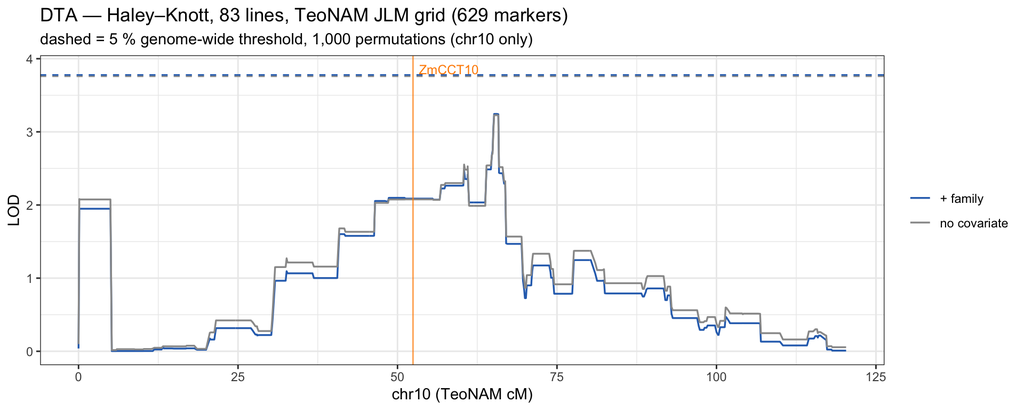

```r
prof <- rbind(data.table(pos = one_nc$pos, lod = one_nc$lod, model = "no covariate"),
              data.table(pos = one_fc$pos, lod = one_fc$lod, model = "+ family"))
cct_cm <- approx(mk$pos, mk$cm, xout = ZMCCT10, rule = 2)$y
pal <- c("no covariate" = "grey60", "+ family" = "#2c6fbb")
ggplot(prof, aes(pos, lod, colour = model)) +
  geom_line(linewidth = 0.6) +
  geom_hline(yintercept = thr[1], linetype = "dashed", colour = pal[["no covariate"]]) +
  geom_hline(yintercept = thr[2], linetype = "dashed", colour = pal[["+ family"]]) +
  geom_vline(xintercept = cct_cm, colour = "darkorange", alpha = 0.7) +
  annotate("text", x = cct_cm, y = max(thr) * 1.02, label = "ZmCCT10", hjust = -0.1, size = 3.2, colour = "darkorange") +
  scale_colour_manual(values = pal) +
  labs(x = "chr10 (TeoNAM cM)", y = "LOD", colour = NULL,
       title = sprintf("DTA — Haley–Knott, %d lines, TeoNAM JLM grid (%d markers)", nind(cross), totmar(cross)),
       subtitle = "dashed = 5 % genome-wide threshold, 1,000 permutations (chr10 only)")
```

## 5. Per-family additive scans

As zealhmm: additive regression of DTA on the HMM expected dosage (B-allele count) within each family, LOD = n/2 · log10(RSS0 / RSS1); a marker is tested only if ≥ 5 % of the family is introgressed there and every present genotype class has ≥ 3 lines.

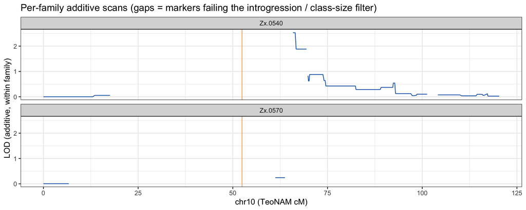

```r
pr <- cross$geno[["10"]]$prob
dose <- pr[, , 2] + 2 * pr[, , 3]
hard <- t(apply(pr, 1:2, which.max) - 1L)
pos_cm <- attr(pr, "map")
byfam <- rbindlist(lapply(levels(fam), function(f) {
  idx <- which(fam == f); yy <- y[idx]; rss0 <- sum((yy - mean(yy))^2)
  rbindlist(lapply(seq_along(pos_cm), function(j) {
    h <- hard[j, idx]; tb <- table(factor(h, levels = 0:2))
    okm <- mean(h > 0) >= INTRO_MIN && all(tb[tb > 0] >= MIN_CLASS)
    lod <- if (okm) { x <- dose[idx, j]; length(idx) / 2 * log10(rss0 / sum(resid(lm(yy ~ x))^2)) } else NA_real_
    data.table(family = f, pos = pos_cm[j], lod = lod, n_intro = sum(h > 0))
  }))
}))
ggplot(byfam, aes(pos, lod)) +
  geom_line(colour = "#2c6fbb", na.rm = TRUE) +
  geom_vline(xintercept = cct_cm, colour = "darkorange", alpha = 0.7) +
  facet_wrap(~family, ncol = 1) +
  labs(x = "chr10 (TeoNAM cM)", y = "LOD (additive, within family)",
       title = "Per-family additive scans (gaps = markers failing the introgression / class-size filter)")
```

```r
knitr::kable(byfam[, .(`tested positions` = sum(!is.na(lod)), `max LOD` = round(max(lod, na.rm = TRUE), 2),
                       `at cM` = round(pos[which.max(lod)], 1), `max lines introgressed` = max(n_intro)), by = family])
```

| family | tested positions | max LOD | at cM | max lines introgressed |
| --- | --- | --- | --- | --- |
| Zx.0540 | 422 | 2.54 | 65.9 | 13 |
| Zx.0570 | 60 | 0.24 | 63.8 | 7 |

## 6. Allele effect at the pooled peak

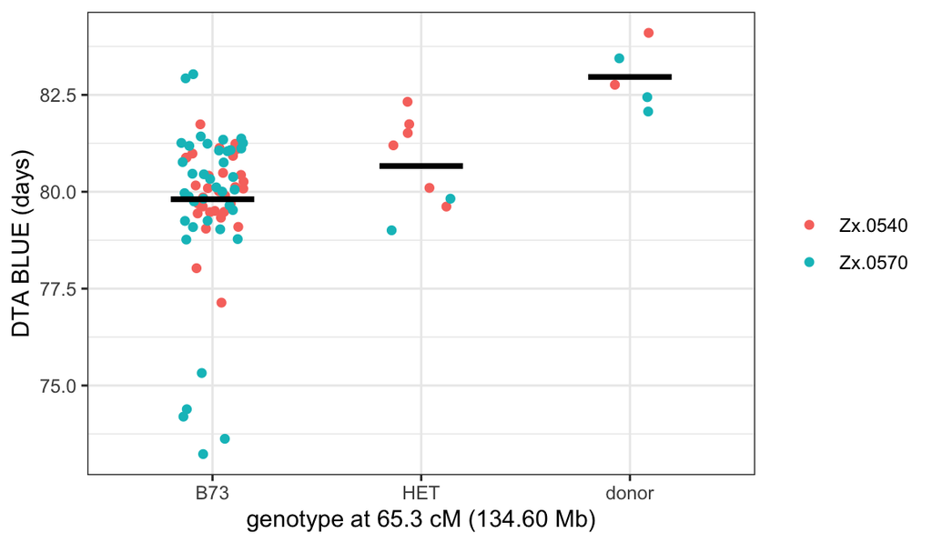

```r
j <- which.max(one_fc$lod)
g <- factor(c("B73", "HET", "donor")[hard[j, ] + 1], levels = c("B73", "HET", "donor"))
ggplot(data.table(g, y, fam), aes(g, y, colour = fam)) +
  geom_jitter(width = 0.15, height = 0, size = 1.5) +
  stat_summary(fun = mean, geom = "crossbar", width = 0.4, colour = "black") +
  labs(x = sprintf("genotype at %.1f cM (%.2f Mb)", one_fc$pos[j], cm_to_bp(one_fc$pos[j]) / 1e6), y = "DTA BLUE (days)", colour = NULL)
```

## 7. Reading

```r
cat(sprintf("- Pooled scan: max LOD %.2f (with family) against a 5 %% threshold of %.2f; %s.\n",
            pk(one_fc)["lod"], thr[2], if (pk(one_fc)["lod"] > thr[2]) "**a QTL passes the threshold**" else "no QTL passes the threshold"))
```

- Pooled scan: max LOD 3.24 (with family) against a 5 % threshold of 3.78; no QTL passes the threshold.

```r
cat(sprintf("- At ZmCCT10 (%.1f cM) the LOD is %.2f with family.\n", cct_cm, one_fc$lod[which.min(abs(one_fc$pos - cct_cm))]))
```

- At ZmCCT10 (52.4 cM) the LOD is 2.09 with family.

```r
cat("- Like the GWAS (notebook 02), the scan is limited by few introgressed lines per locus in two families on one chromosome;",
    "the threshold here is chromosome-wide (chr10 only), so it is lower than a genome-wide one would be.\n")
```

- Like the GWAS (notebook 02), the scan is limited by few introgressed lines per locus in two families on one chromosome; the threshold here is chromosome-wide (chr10 only), so it is lower than a genome-wide one would be.